# Week11_Monday slides

## Week 11 Monday

Monday, April 6, 2026

**Announcements**

- A07 due Wednesday, April 8.
- A05 FINAL drafts due tonight.
- A08 (project proposal) released. Due Friday, 4/17

**Goals**

- Debrief on writing workshop
- Individual check-ins on writing and A06/A07 while you work on:
  - A07
  - Lit review edits
  - Feedback control class exercise

## A07 tips

Three ways to measure position and orientation (yaw) of Romi:

1. Ground truth from supervisor
2. Using **measurements from** the encoders to get $\omega_l,\omega_r$, then using Odometry
3. Using **A06 model** to map **input voltages (in counts -> volts)** to get *predictions* of $\omega_r,\omega_l$, and **then** using those predicted angular velocities to perform Odometry

A07 asks you to compare all three of these methods! Remember that your model predicts forward speed $U$ and angular velocity $\dot{\psi}$ directly. But then, we know that:

$$\dot{\psi} = \frac{\omega_rR_{wheel} - \omega_lR_{wheel}}{2R_{romi}}$$

$$U = R_{wheel}\frac{\omega_l+\omega_r}{2}$$

This means that given a predicted $U$ and a predicted $\dot{\psi}$ at any moment in time, you can compute $\omega_l$ and $\omega_r$. **The assignment suggests recording input voltages and time in one file, and raw encoder values in another.** This means you'd do all predictions and odometry calcs "offline" after the simulation is over... but this is your choice.

## Romi feedback control hints:

Helpful to:

- Consider some "special cases" that are easy to model
- Try feedback control using GPS for position rather than odometry

## Romi Feedback Control Special Case 1:

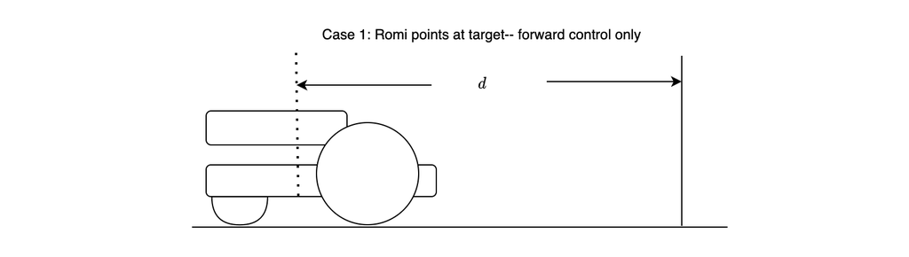

$$ \ddot{x}_{romi} = \dot{U} = \frac{a_{0U}}{a_{1U}} U + \frac{b_{0U}}{a_{1U}} V_{in} $$ $$ V_{in} = K_U (d) = K_U \left(x_d-x_{romi}\right)$$ $$\therefore \ddot{x}_{romi} = \frac{a_{0U}}{a_{1U}} U + \frac{b_{0U}}{a_{1U}} K_U \left(x_d-x_{romi}\right)$$

## Romi Feedback Control Special Case 2:

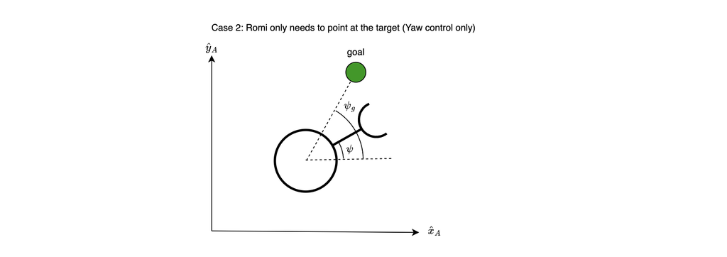

$$ \ddot{\psi} = \frac{a_{0\psi}}{a_{1\psi}} \dot{\psi} + \frac{b_{0\psi}}{a_{1\psi}} \Delta V_{in} $$ $$ \Delta V_{in} = K_\psi \left(\psi_g-\psi \right)$$ $$\therefore \ddot{\psi} = \frac{a_{0\psi}}{a_{1\psi}} \dot{\psi} + \frac{b_{0\psi}}{a_{1\psi}} K_\psi \left(\psi_g-\psi\right)$$

.

.

.

## Class exercise 2: Make the Romi reach a desired location using feedback control

- Specify a goal location in the Romi's world
- Use feedback control to get commanded forward velocity and yaw rate for the Romi (use odometry estimates!)
- Use inverse differential kinematics to turn those commands into Romi wheel speeds

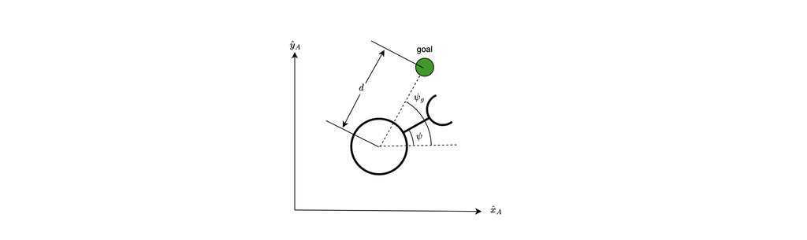